# Première partie: Machine learning

### Import nécessaires

```python
import pandas as pd
import matplotlib.pyplot as plt
import matplotlib as mpl
import numpy as np
import seaborn as sns
from sklearn import preprocessing
```

### Chargement de la base

```python
data = pd.read_csv("dataset.csv", sep =",")
data.head()
```

|  | height | width | depth | weight | activity |
| --- | --- | --- | --- | --- | --- |
| 0 | 90.5 | 42.0 | 2.0 | 1.25 | mlp |
| 1 | 60.0 | 50.0 | 2.0 | 1.20 | mlp |
| 2 | 80.0 | 59.6 | 2.0 | 7.40 | mlp |
| 3 | 46.0 | 46.0 | 2.0 | 1.45 | mlp |
| 4 | 93.0 | 21.0 | 2.0 | 1.30 | mlp |

### Exploration de la base

```python
print(data.isnull().sum(axis = 0))
```

```
height      0
width       0
depth       0
weight      0
activity    0
dtype: int64
```

On remarque qu'il ne manque aucune donnée, nous n'avons donc pas besoin de faire une imputation

Pour la suite, afin d'appliquer le modèle de classification nous avons besoin d'encoder la colonne "activity" qui va consister à transformer les données alphanumériques en données numériques, les seules manipulables par les algorithmes. MLP : prend l'encodage 2 / DECO: prend l'encodage 0 / MEUBLE : prend l'encodage 1

```python
label_encoder = preprocessing.LabelEncoder()
data['activity_encoder'] = label_encoder.fit_transform(data['activity'])
```

```python
data
```

|  | height | width | depth | weight | activity | activity_encoder |
| --- | --- | --- | --- | --- | --- | --- |
| 0 | 90.5 | 42.0 | 2.0 | 1.25 | mlp | 2 |
| 1 | 60.0 | 50.0 | 2.0 | 1.20 | mlp | 2 |
| 2 | 80.0 | 59.6 | 2.0 | 7.40 | mlp | 2 |
| 3 | 46.0 | 46.0 | 2.0 | 1.45 | mlp | 2 |
| 4 | 93.0 | 21.0 | 2.0 | 1.30 | mlp | 2 |
| ... | ... | ... | ... | ... | ... | ... |
| 895 | 81.0 | 295.0 | 175.0 | 84.00 | meuble | 1 |
| 896 | 100.0 | 170.0 | 207.0 | 41.00 | meuble | 1 |
| 897 | 125.0 | 200.0 | 215.0 | 96.30 | meuble | 1 |
| 898 | 80.0 | 270.0 | 270.0 | 93.00 | meuble | 1 |
| 899 | 255.0 | 350.0 | 350.0 | 8.00 | meuble | 1 |

900 rows × 6 columns

```python
data['activity_encoder'].unique()
```

```
array([2, 0, 1])
```

```python
activity_encoder = data.activity_encoder
```

```python
activity_encoder
```

```
0      2
1      2
2      2
3      2
4      2
      ..
895    1
896    1
897    1
898    1
899    1
Name: activity_encoder, Length: 900, dtype: int32
```

```python
for i in [0,1,2]:
    print("classe : %s, nb exemplaires: %s" % (i, len(activity_encoder[ activity_encoder == i]) ) )
```

```
classe : 0, nb exemplaires: 300
classe : 1, nb exemplaires: 300
classe : 2, nb exemplaires: 300
```

### Observation des données

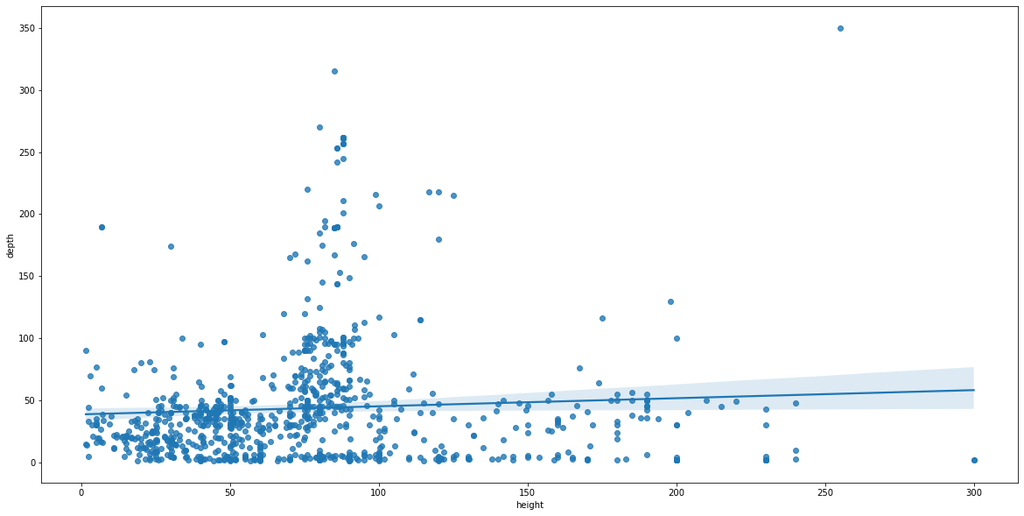

```python
fig = plt.figure(figsize=(20, 10))
sns.regplot(x=data['height'], y=data['depth'], fit_reg=True)
plt.show()
```

Ci-dessus, nous avons réalisé un tracé linéaire. Il est assez facile de voir qu’une fonction linéaire ne fonctionnera pas car beaucoup de points sont assez éloignés de la ligne.

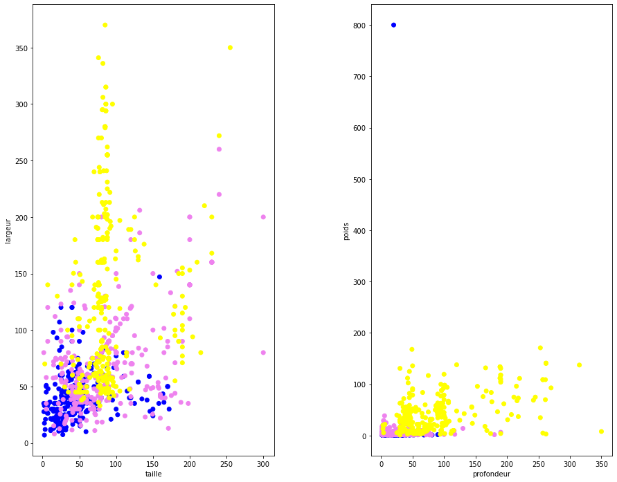

```python
fig = plt.figure(figsize=(15, 12))
fig.subplots_adjust(hspace=0.4, wspace=0.4)

ax1 = plt.subplot(1,2,1)

clist = ['violet', 'yellow', 'blue']
colors = [clist[c] for c in data.activity_encoder]

ax1.scatter(data['height'], data['width'], c=colors)
plt.xlabel('taille')
plt.ylabel('largeur')

ax2 = plt.subplot(1,2,2)

ax2.scatter(data['depth'], data['weight'], color=colors)

plt.xlabel('profondeur')
plt.ylabel('poids')
```

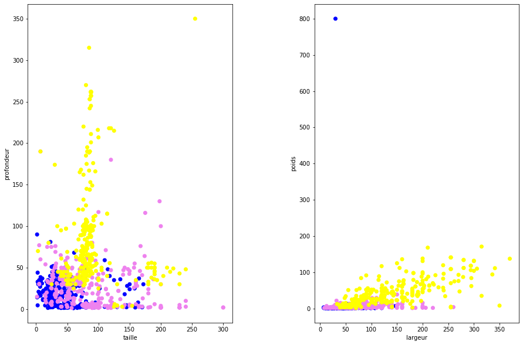

```python
fig = plt.figure(figsize=(15, 10))
fig.subplots_adjust(hspace=0.4, wspace=0.4)

ax3 = plt.subplot(1,2,1)

clist = ['violet', 'yellow', 'blue']
colors = [clist[c] for c in data.activity_encoder]

ax3.scatter(data['height'], data['depth'], c=colors)
plt.xlabel('taille')
plt.ylabel('profondeur')

ax4 = plt.subplot(1,2,2)

ax4.scatter(data['width'], data['weight'], color=colors)

plt.xlabel('largeur')
plt.ylabel('poids')
```

Sur ces observations on remarque qu'on a du mal à différencier les 3 activités. En effet, les 3 activités sont confondues et ne se différencient pas. Ce qui nous laisse à penser qu'on aura une plus grande marge d'erreur après l'algorithme de prédiction.

```python
activity=data.activity
activity
```

```
0         mlp
1         mlp
2         mlp
3         mlp
4         mlp
        ...
895    meuble
896    meuble
897    meuble
898    meuble
899    meuble
Name: activity, Length: 900, dtype: object
```

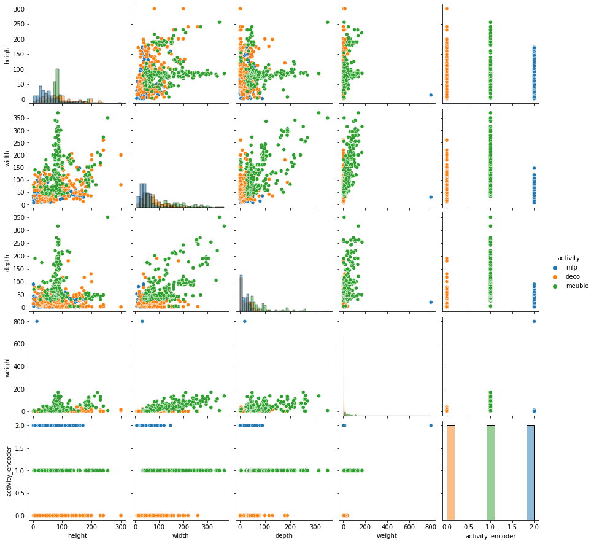

```python
sns.pairplot(data, hue="activity", diag_kind="hist")
```

Initialement, on cherche à classifier des valeurs et pas de prédire, on peut donc éloigner les algorithmes liés à une régression linéaire. Ensuite, nous savons que la régression logistique est adaptée pour les valeurs binaires, ce qui n'est pas dans notre cas. Le choix c'est donc porter sur les modèles (KNN et Naïve bayes). Ces observations confirment donc notre choix de modèle.

### Apprentissage

#### KNN

```python
from sklearn import neighbors
clf = neighbors.KNeighborsClassifier()
```

Diviser en valeurs d’entrée et de sortie

On affecte ensuite les colonnes de données aux X (variables) et à Y (grandeur à prédire ou Target) puis sera découpé en deux parties (Train Set et Test Set). Ensuite, on pourra passer à la déclaration du modèle (model =), à son entrainement (model.fit) sur le Train Set, au calcul du score (model.score) et enfin à la prédiction (model.predict) sur le Test Set.

```python
x = data.iloc[:,[0,1,2,3]].values
y = data.iloc[:,4].values
print(x,y)
```

[output not shown]

[output cut: 44 more lines]

[output not shown]

```python
from sklearn.model_selection import train_test_split
from sklearn.metrics import accuracy_score
x_train, x_test, y_train, y_test = train_test_split(x,y,random_state = 0)
```

Après avoir séparé les variables des targets, on normalise les données pour accroitre les performances des codes.

```python
from sklearn.preprocessing import MinMaxScaler

scaler = MinMaxScaler()
x_train = scaler.fit_transform(x_train)
x_test = scaler.transform(x_test)
```

Les données sont, à présent, prêtes à être utilisé pour appliquer le modèle.

```python
from sklearn.neighbors import KNeighborsClassifier
model = KNeighborsClassifier(n_neighbors= 5, metric= 'euclidean')
```

```python
model.fit(x_train,y_train)
```

```
KNeighborsClassifier(metric='euclidean')
```

```python
y_pred = model.predict(x_test)
y_pred
```

```
array(['deco', 'mlp', 'mlp', 'deco', 'meuble', 'deco', 'meuble', 'deco',
       'mlp', 'mlp', 'meuble', 'mlp', 'deco', 'meuble', 'deco', 'mlp',
       'deco', 'meuble', 'meuble', 'meuble', 'mlp', 'meuble', 'meuble',
       'meuble', 'deco', 'mlp', 'mlp', 'meuble', 'mlp', 'deco', 'mlp',
       'meuble', 'meuble', 'deco', 'meuble', 'meuble', 'deco', 'deco',
       'meuble', 'deco', 'meuble', 'deco', 'mlp', 'deco', 'meuble',
       'deco', 'deco', 'mlp', 'mlp', 'meuble', 'meuble', 'deco', 'deco',
       'deco', 'meuble', 'mlp', 'mlp', 'meuble', 'deco', 'meuble', 'deco',
       'mlp', 'mlp', 'meuble', 'mlp', 'meuble', 'mlp', 'meuble', 'meuble',
       'meuble', 'meuble', 'meuble', 'deco', 'meuble', 'mlp', 'mlp',
       'meuble', 'mlp', 'deco', 'deco', 'mlp', 'meuble', 'mlp', 'mlp',
       'meuble', 'deco', 'meuble', 'deco', 'mlp', 'deco', 'mlp', 'deco',
       'deco', 'meuble', 'meuble', 'meuble', 'mlp', 'meuble', 'meuble',
       'deco', 'meuble', 'deco', 'mlp', 'meuble', 'meuble', 'meuble',
       'deco', 'mlp', 'mlp', 'deco', 'mlp', 'deco', 'deco', 'deco',
       'meuble', 'meuble', 'meuble', 'meuble', 'mlp', 'mlp', 'meuble',
       'deco', 'mlp', 'meuble', 'mlp', 'mlp', 'deco', 'mlp', 'meuble',
       'mlp', 'mlp', 'meuble', 'meuble', 'meuble', 'mlp', 'deco',
       'meuble', 'mlp', 'deco', 'deco', 'meuble', 'meuble', 'mlp',
       'meuble', 'mlp', 'meuble', 'mlp', 'mlp', 'deco', 'meuble',
       'meuble', 'meuble', 'mlp', 'deco', 'mlp', 'deco', 'mlp', 'meuble',
       'meuble', 'deco', 'deco', 'mlp', 'mlp', 'deco', 'deco', 'meuble',
       'mlp', 'mlp', 'meuble', 'mlp', 'mlp', 'mlp', 'mlp', 'deco', 'mlp',
       'deco', 'deco', 'deco', 'mlp', 'mlp', 'deco', 'meuble', 'mlp',
       'mlp', 'deco', 'deco', 'meuble', 'meuble', 'meuble', 'meuble',
       'deco', 'mlp', 'meuble', 'deco', 'deco', 'mlp', 'deco', 'meuble',
       'mlp', 'deco', 'mlp', 'mlp', 'deco', 'deco', 'mlp', 'meuble',
       'mlp', 'deco', 'meuble', 'mlp', 'mlp', 'deco', 'mlp', 'meuble',
       'meuble', 'deco', 'meuble', 'deco', 'mlp', 'mlp', 'deco', 'mlp',
       'deco', 'mlp', 'mlp'], dtype=object)
```

```python
y_test
```

```
array(['deco', 'mlp', 'deco', 'mlp', 'deco', 'deco', 'meuble', 'deco',
       'deco', 'mlp', 'meuble', 'mlp', 'deco', 'meuble', 'deco', 'deco',
       'deco', 'meuble', 'meuble', 'meuble', 'mlp', 'meuble', 'meuble',
       'meuble', 'deco', 'mlp', 'mlp', 'meuble', 'deco', 'deco', 'mlp',
       'deco', 'meuble', 'deco', 'meuble', 'meuble', 'deco', 'deco',
       'meuble', 'deco', 'meuble', 'mlp', 'mlp', 'deco', 'meuble', 'deco',
       'mlp', 'mlp', 'mlp', 'meuble', 'meuble', 'mlp', 'deco', 'mlp',
       'meuble', 'mlp', 'mlp', 'meuble', 'deco', 'deco', 'deco', 'mlp',
       'mlp', 'meuble', 'mlp', 'meuble', 'deco', 'meuble', 'meuble',
       'deco', 'meuble', 'meuble', 'mlp', 'meuble', 'deco', 'deco',
       'meuble', 'mlp', 'mlp', 'deco', 'deco', 'meuble', 'deco', 'mlp',
       'meuble', 'deco', 'meuble', 'deco', 'mlp', 'deco', 'mlp', 'deco',
       'deco', 'meuble', 'meuble', 'meuble', 'mlp', 'meuble', 'meuble',
       'deco', 'deco', 'deco', 'mlp', 'meuble', 'meuble', 'deco', 'deco',
       'mlp', 'deco', 'meuble', 'mlp', 'mlp', 'deco', 'deco', 'meuble',
       'meuble', 'meuble', 'meuble', 'mlp', 'mlp', 'meuble', 'deco',
       'deco', 'meuble', 'mlp', 'deco', 'meuble', 'mlp', 'meuble', 'mlp',
       'mlp', 'meuble', 'deco', 'meuble', 'mlp', 'deco', 'meuble', 'deco',
       'deco', 'meuble', 'meuble', 'meuble', 'mlp', 'meuble', 'mlp',
       'meuble', 'mlp', 'mlp', 'mlp', 'meuble', 'mlp', 'meuble', 'deco',
       'deco', 'mlp', 'deco', 'deco', 'meuble', 'meuble', 'deco', 'deco',
       'mlp', 'mlp', 'meuble', 'deco', 'meuble', 'mlp', 'mlp', 'meuble',
       'mlp', 'mlp', 'deco', 'mlp', 'deco', 'mlp', 'deco', 'mlp',
       'meuble', 'mlp', 'mlp', 'deco', 'meuble', 'mlp', 'mlp', 'deco',
       'deco', 'meuble', 'meuble', 'meuble', 'meuble', 'deco', 'mlp',
       'meuble', 'mlp', 'deco', 'deco', 'deco', 'meuble', 'mlp', 'deco',
       'mlp', 'deco', 'deco', 'deco', 'mlp', 'meuble', 'deco', 'deco',
       'meuble', 'mlp', 'mlp', 'deco', 'mlp', 'meuble', 'meuble', 'deco',
       'meuble', 'meuble', 'mlp', 'mlp', 'deco', 'mlp', 'deco', 'mlp',
       'mlp'], dtype=object)
```

```python
accuracy_score(y_test,y_pred)*100
```

```
80.44444444444444
```

Le modèle de prédiction y_pred appliqué à l'echantillon y_test donne un score de 80 %.

Nous pouvons conclure à partir de ce résultat 80 valeurs seront prédites correctement sur 100 valeurs.

Afin de visualiser les résultats et de comparer les données réelles pour une variable cible à celles prédites par un modèle, nous allons calculer la matrice de confusion.

```python
from sklearn.metrics import confusion_matrix
conf=confusion_matrix(y_test,y_pred)
conf
```

```
array([[52,  7, 19],
       [ 6, 70,  0],
       [11,  1, 59]], dtype=int64)
```

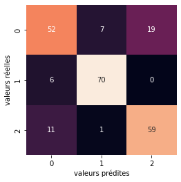

```python
sns.heatmap(conf, square=True, annot=True, cbar=False)
plt.xlabel('valeurs prédites')
plt.ylabel('valeurs réelles');
```

Pour rappel: 0= DECO / 1= MEUBLE / 2: MLP

#### Naive Bayes

```python
from sklearn.naive_bayes import GaussianNB
```

```python
clf2 = GaussianNB()
```

```python
clf2.fit(x_train,y_train)
```

```
GaussianNB()
```

```python
result = clf2.predict(x_test)
result
```

```
array(['deco', 'mlp', 'deco', 'deco', 'deco', 'deco', 'deco', 'deco',
       'mlp', 'mlp', 'meuble', 'deco', 'deco', 'deco', 'deco', 'deco',
       'meuble', 'meuble', 'deco', 'meuble', 'deco', 'meuble', 'meuble',
       'deco', 'deco', 'mlp', 'deco', 'deco', 'mlp', 'deco', 'deco',
       'meuble', 'meuble', 'deco', 'meuble', 'deco', 'deco', 'deco',
       'deco', 'deco', 'meuble', 'mlp', 'mlp', 'deco', 'meuble', 'deco',
       'deco', 'deco', 'deco', 'meuble', 'meuble', 'deco', 'deco', 'deco',
       'meuble', 'deco', 'mlp', 'meuble', 'deco', 'deco', 'deco', 'deco',
       'deco', 'meuble', 'mlp', 'meuble', 'deco', 'meuble', 'meuble',
       'deco', 'meuble', 'meuble', 'deco', 'meuble', 'deco', 'deco',
       'deco', 'mlp', 'mlp', 'deco', 'deco', 'meuble', 'deco', 'deco',
       'deco', 'deco', 'meuble', 'deco', 'deco', 'deco', 'deco', 'mlp',
       'deco', 'meuble', 'meuble', 'meuble', 'deco', 'meuble', 'meuble',
       'deco', 'deco', 'deco', 'deco', 'meuble', 'deco', 'deco', 'deco',
       'deco', 'deco', 'meuble', 'mlp', 'deco', 'deco', 'meuble',
       'meuble', 'meuble', 'meuble', 'meuble', 'deco', 'deco', 'deco',
       'deco', 'deco', 'meuble', 'deco', 'deco', 'deco', 'deco', 'deco',
       'deco', 'deco', 'meuble', 'deco', 'deco', 'deco', 'deco', 'meuble',
       'deco', 'deco', 'deco', 'mlp', 'meuble', 'mlp', 'meuble', 'deco',
       'deco', 'mlp', 'deco', 'deco', 'meuble', 'deco', 'meuble', 'deco',
       'deco', 'deco', 'deco', 'deco', 'meuble', 'meuble', 'deco', 'deco',
       'deco', 'deco', 'deco', 'deco', 'deco', 'deco', 'deco', 'meuble',
       'deco', 'deco', 'deco', 'mlp', 'deco', 'mlp', 'deco', 'deco',
       'meuble', 'deco', 'deco', 'deco', 'deco', 'mlp', 'deco', 'deco',
       'deco', 'meuble', 'meuble', 'meuble', 'deco', 'deco', 'mlp',
       'meuble', 'deco', 'deco', 'deco', 'deco', 'meuble', 'deco', 'deco',
       'mlp', 'deco', 'deco', 'deco', 'mlp', 'meuble', 'deco', 'deco',
       'meuble', 'mlp', 'deco', 'deco', 'deco', 'deco', 'deco', 'deco',
       'meuble', 'deco', 'deco', 'deco', 'deco', 'deco', 'deco', 'mlp',
       'deco'], dtype='<U6')
```

```python
accuracy_score(y_test, result)*100
```

```
64.0
```

Nous pouvons conclure à partir de ce résultat 64 valeurs seront prédites correctement contre 80 avec le KNN sur 100 valeurs. Le modèle KNN a donc plus de chance de prédire correctement.

```python
conf2 = confusion_matrix(y_test, result)
conf2
```

```
array([[72,  3,  3],
       [23, 52,  1],
       [51,  0, 20]], dtype=int64)
```

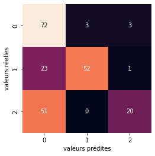

```python
sns.heatmap(conf2, square=True, annot=True, cbar=False)
plt.xlabel('valeurs prédites')
plt.ylabel('valeurs réelles');
```

Pour rappel: 0= DECO / 1= MEUBLE / 2: MLP

Après avoir appliqué les 2 modèles voulus, on remarque que le modèle KNN est donc plus efficace sur le dataset.